# Data Exploration

Peter Yates

07 May, 2019

### This document applies the protocol for data exploration by Zuur et al 2010 (doi 10.1111/j.2041-210X.2009.00001.x).

This includes:

- Collinearity
- Relationships between x variables
- Relationships between x and y variables
- Interactions - are any apparent and is there enough data to test for them?
- Independence - I suspect these data violate this assumption hence I’ll include a spatial autocorrelation term and looking for spatial dependence in model residuals.
- Outliers in x and y and x~y
- Homogeneity and balance accross factor levels and two-way factor-level combinations
- Occurence of zeros and NAs

### Relationships between variables

#### Scatterplots and Pearson correlations amoung continuous x vars

NB: Order of the plots is from North - South (CB, EH, NS, DH), followed by all sites pooled. CB did not have a CTD tow done hence it’s pairplot contains fewer variables. Based on these plots I am removing:

- Salt (as measured by the SeaSoar. It is correlated with Temp),
- D_coast (correlated with GA_depth),
- Phosphate and Silicate (correlated with Nitrate).

Keep an eye on:

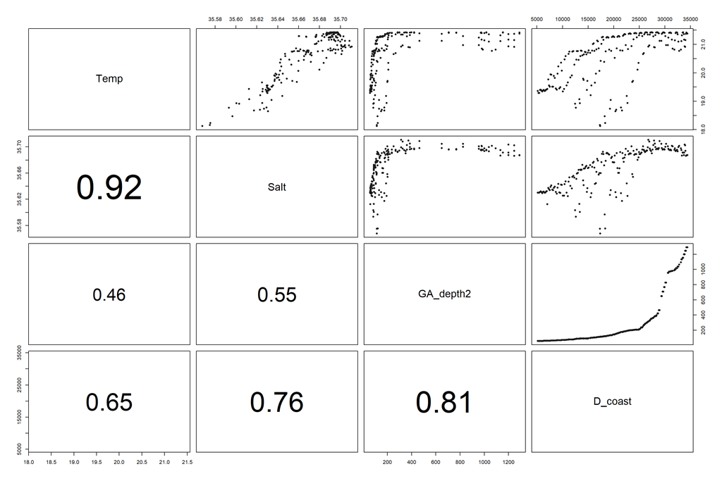

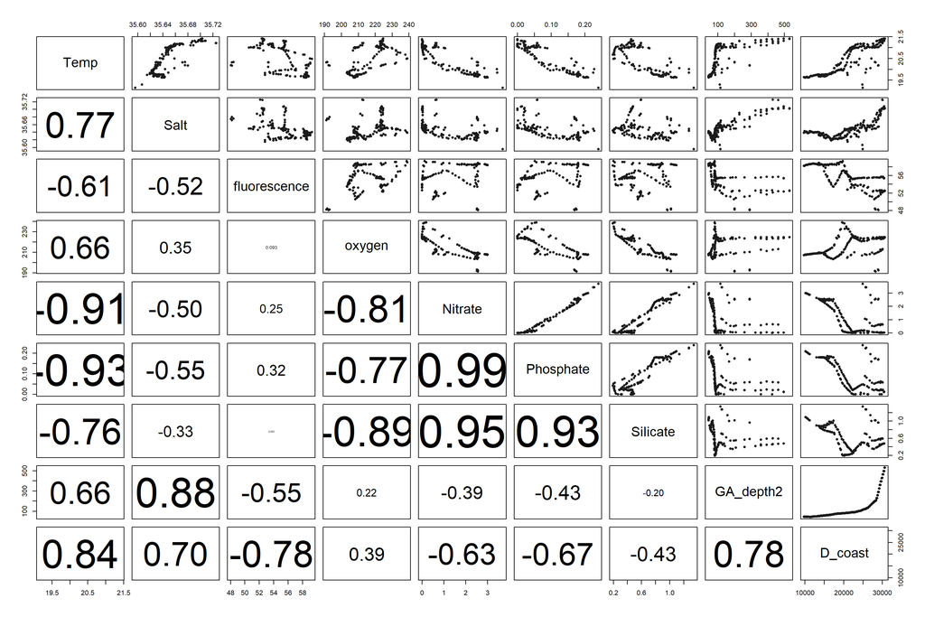

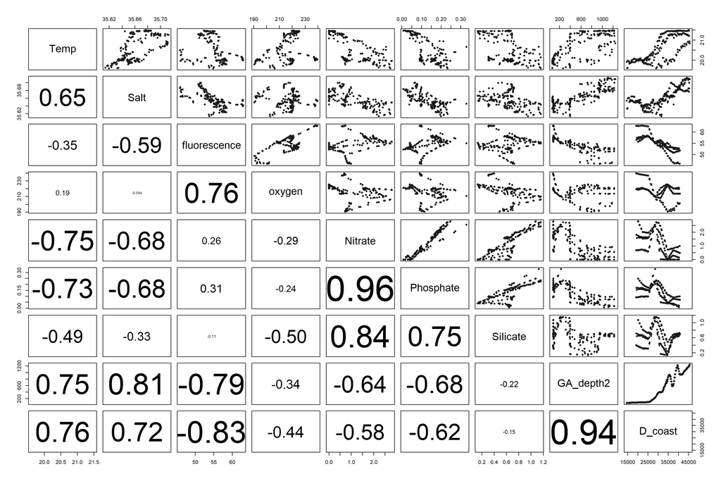

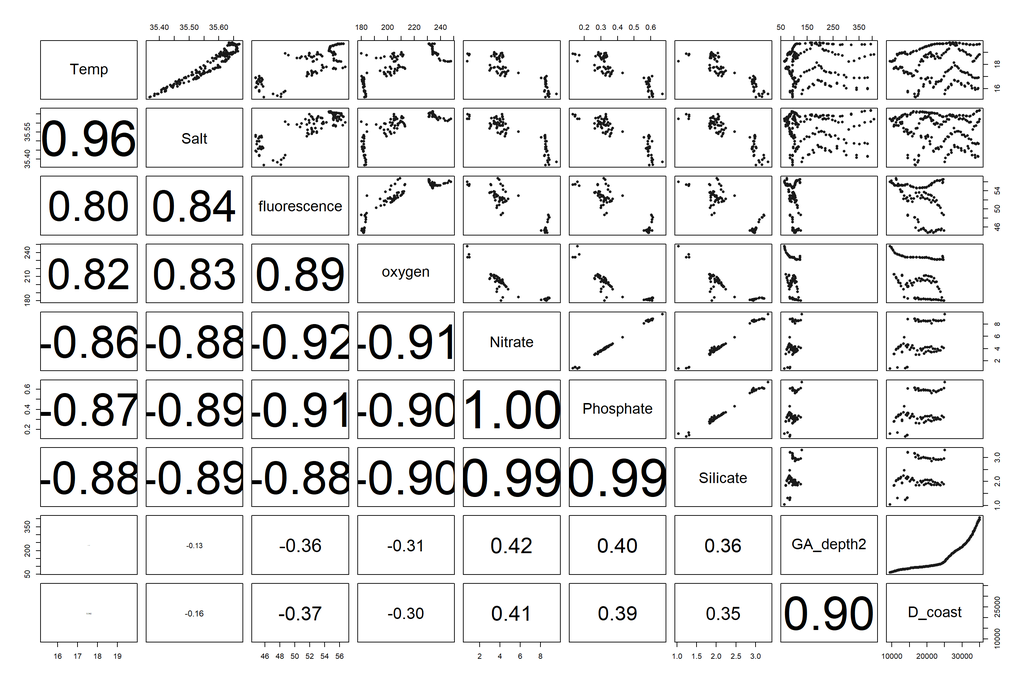

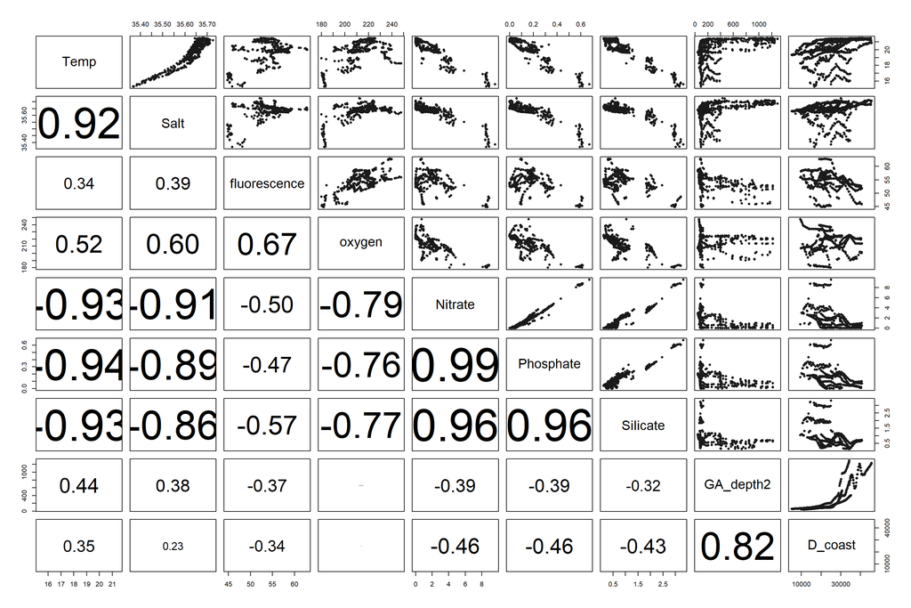

#### Variance inflation factors (should not be > 3)

The VIF of a predictor is a measure for how easily it is predicted from a linear regression using the other predictors. Ask stat: does Lon and site need to be here? VIF for categorical? Does site and Dbin need to be added OUTSIDE? i’m actually not interested in Depth…just want to account for it…(?)

```r
MyVar2 <- c("Temp", "fluorescence","oxygen", "Nitrate", "GA_depth2", "Lon")
corvif(df[,MyVar2])
```

```
##
##
## Variance inflation factors
##
##                   GVIF
## Temp         15.333502
## fluorescence  3.780411
## oxygen        6.015260
## Nitrate      11.270922
## GA_depth2     2.687472
## Lon           5.301038
```

```r
#remove nitrate
MyVar2b <- c("Temp", "fluorescence","oxygen", "GA_depth2", "Lon")
corvif(df[,MyVar2b])
```

```
##
##
## Variance inflation factors
##
##                   GVIF
## Temp         10.103699
## fluorescence  2.758183
## oxygen        4.173460
## GA_depth2     2.451413
## Lon           5.758239
```

```
##
##
## Variance inflation factors
##
##                  GVIF
## Temp         2.397585
## fluorescence 2.635902
## GA_depth2    2.231921
## oxygen       2.196594
```

### Collinearity between categorical and continuous X vars (Dbin, Vbin, Ubin, slope, site)

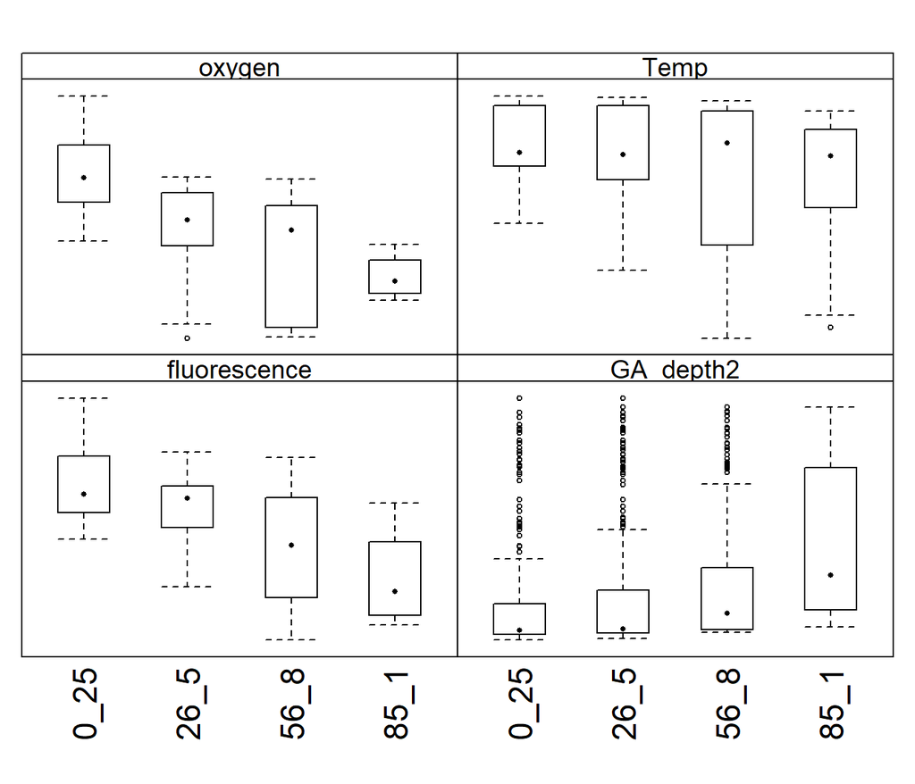

Vbin (note the potential correlation between Temp and alongshore current. Makes sense - warmer water with southerly current)

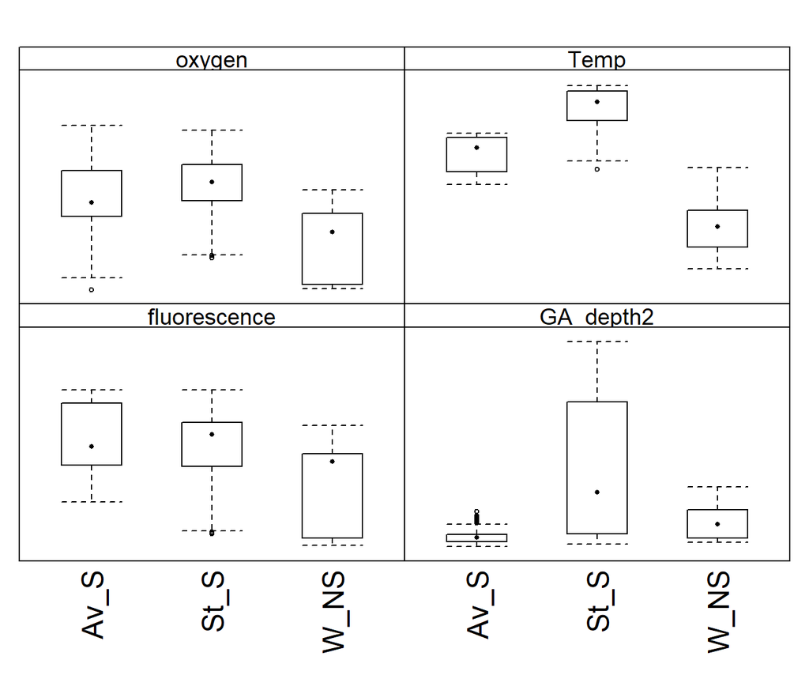

Ubin

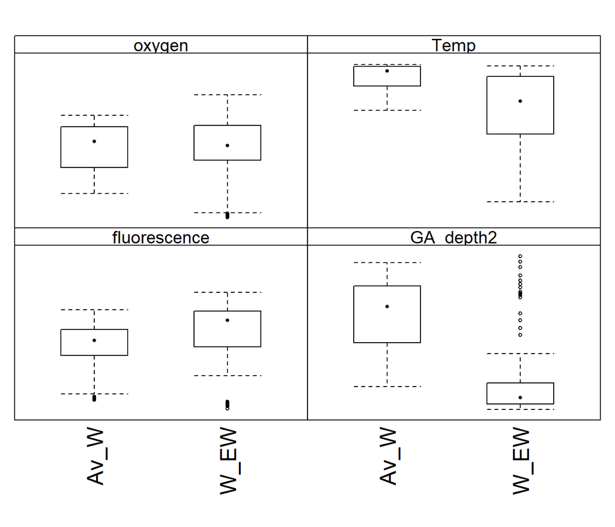

Site

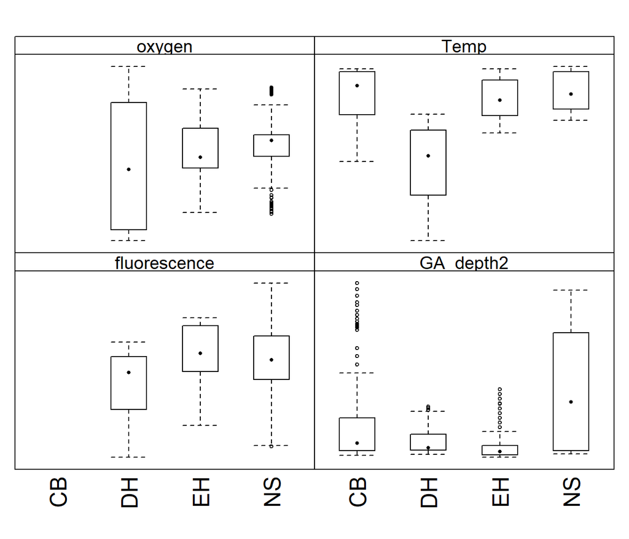

Seafloor slope

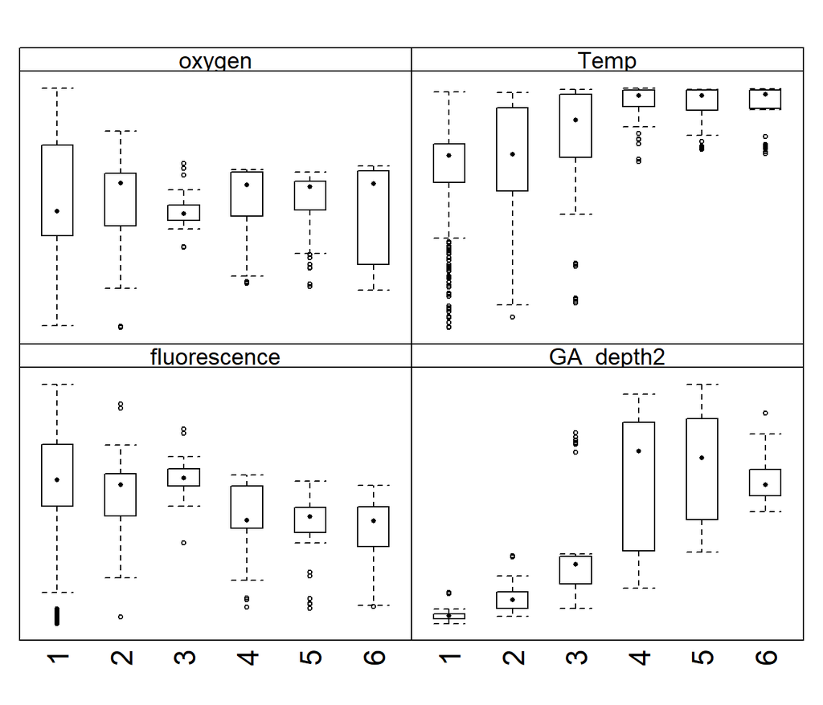

## Confounding between categorical X variables (Dbin, Vbin, Ubin, site)

All levels do have enough observations (10-15). Hence they are balanced in one dimension.

However, below are tables of all two-way factor level combinations. There are some issues here.

Decision: Site is a key variable yet it is confounded with Ubin and Vbin. I need to exclude Ubin and Vbin. This will also solve my issues with the NA’s in these variables.

```
##
##          Average_S Strong_S Weak_NS
##   0_25           8       10       0
##   26_55         50      157      31
##   56_85          0       87      32
##   85_115         0       59      20
```

```
##
##          CapeByron DiamondHead EvansHead NorthSolitary
##   0_25          65          71        81            77
##   26_55         65          67        60            77
##   56_85         44          50        22            63
##   85_115        32          22        10            42
```

```
##
##             CapeByron DiamondHead EvansHead NorthSolitary
##   Average_S         0          32         6            20
##   Strong_S        116           0        57           140
##   Weak_NS           0          83         0             0
```

### Relationships between X and Y

#### Continuous X variables

NB: Order of the plots is from North - South (CB, EH, NS, DH), followed by all sites pooled. NB: Some non-linear relationships are apparent.

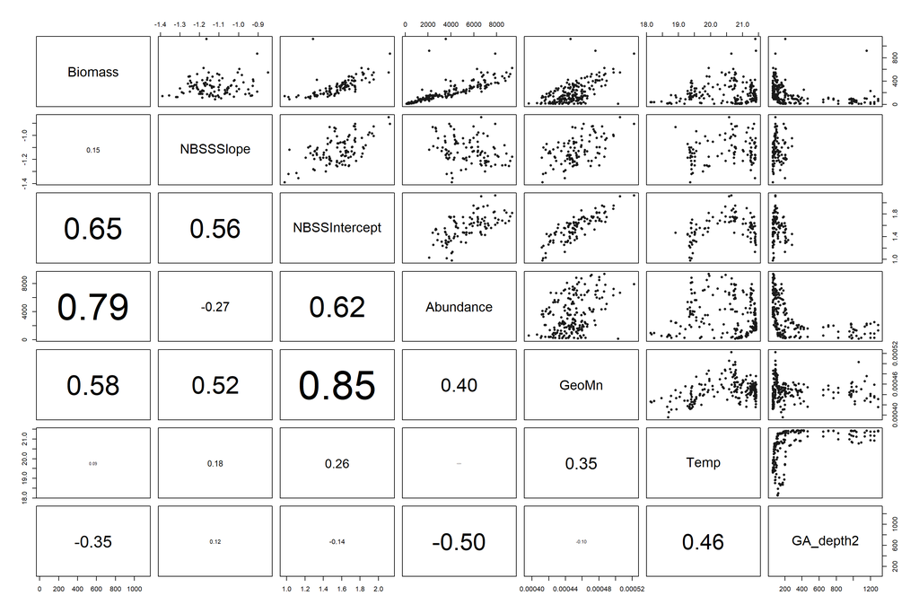

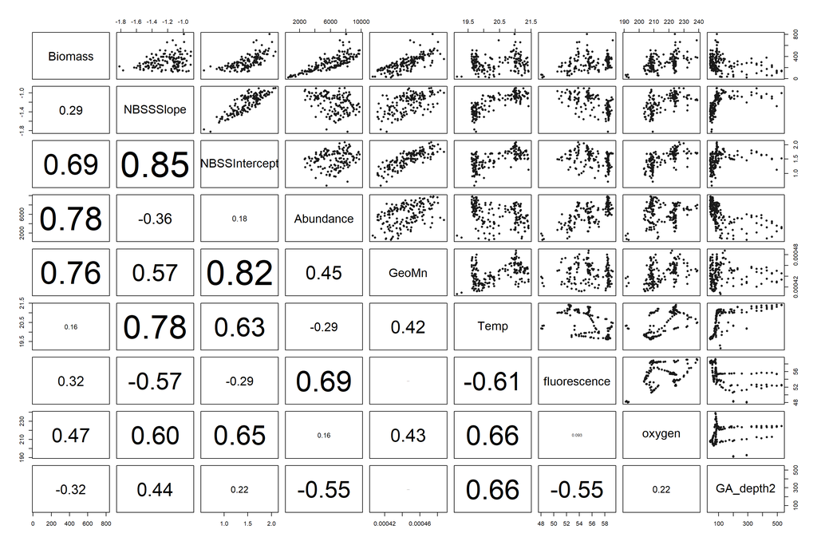

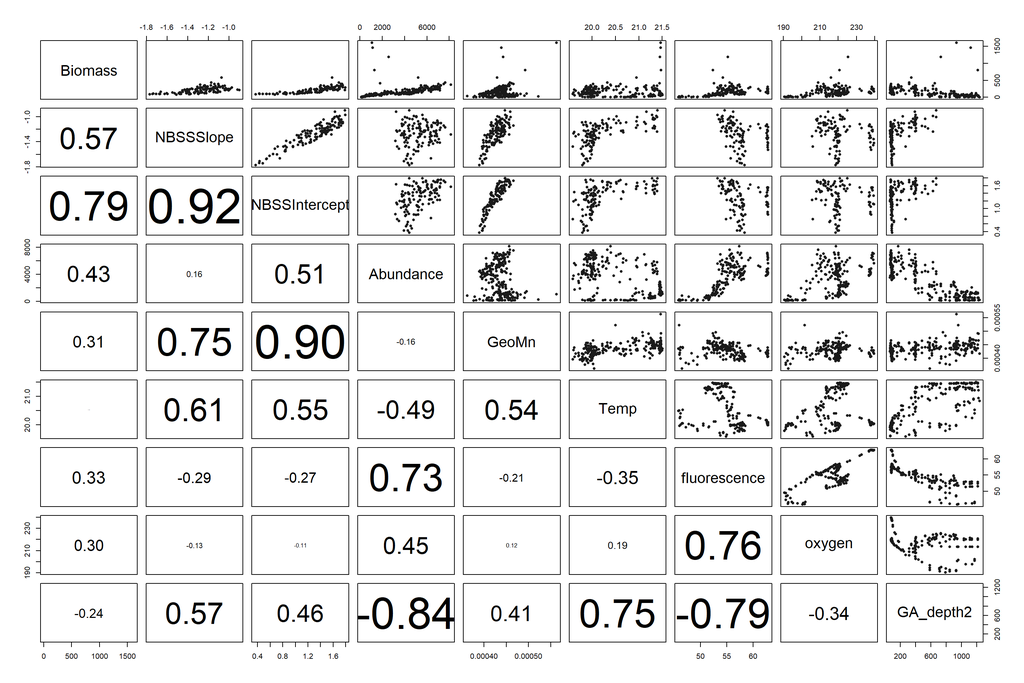

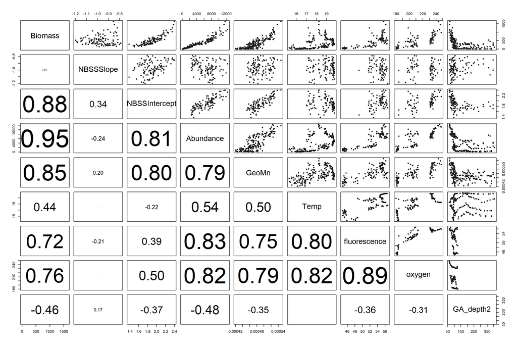

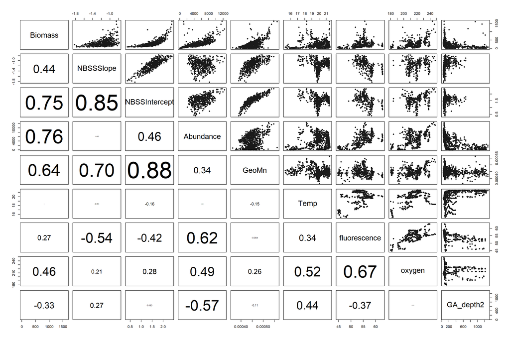

#### Categorical X Variables

These plots are for Dbin and site, repectively. Also to check for homogeneity across factor levels.

Dbin

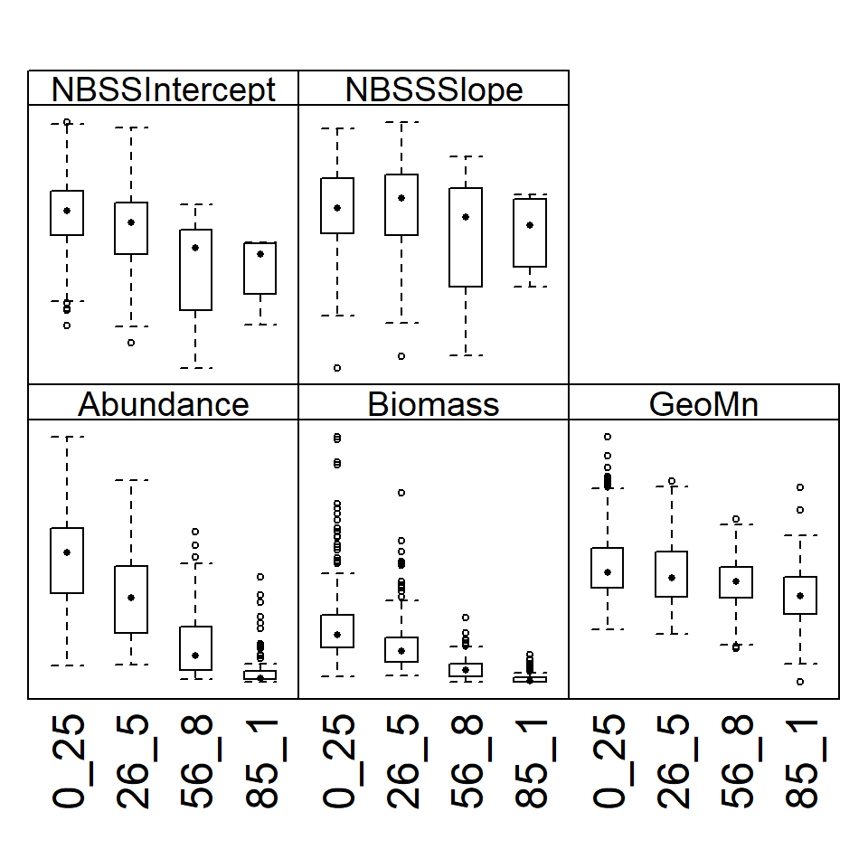

Vbin

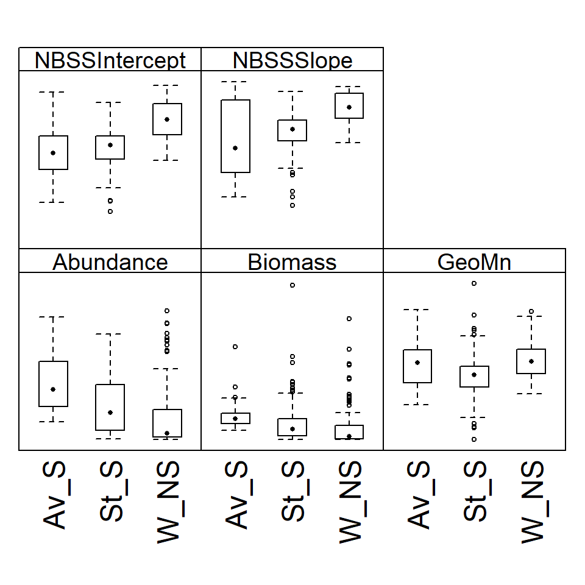

Ubin

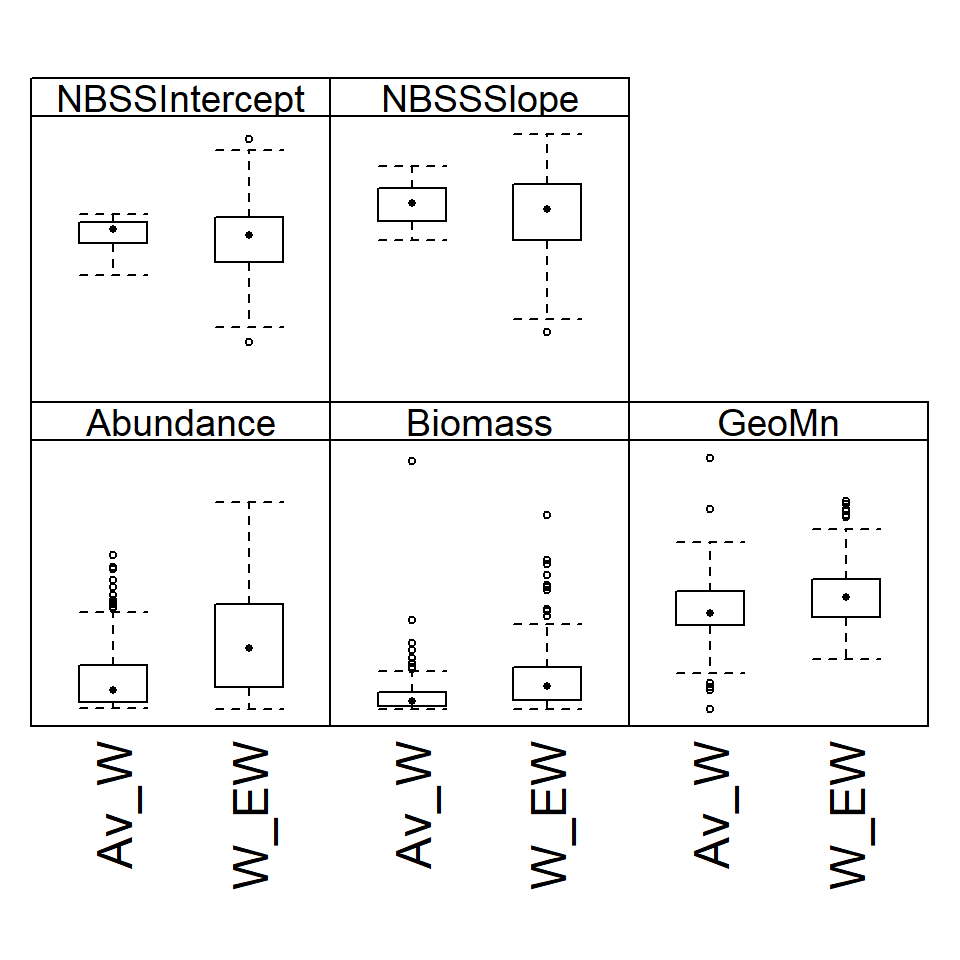

Site

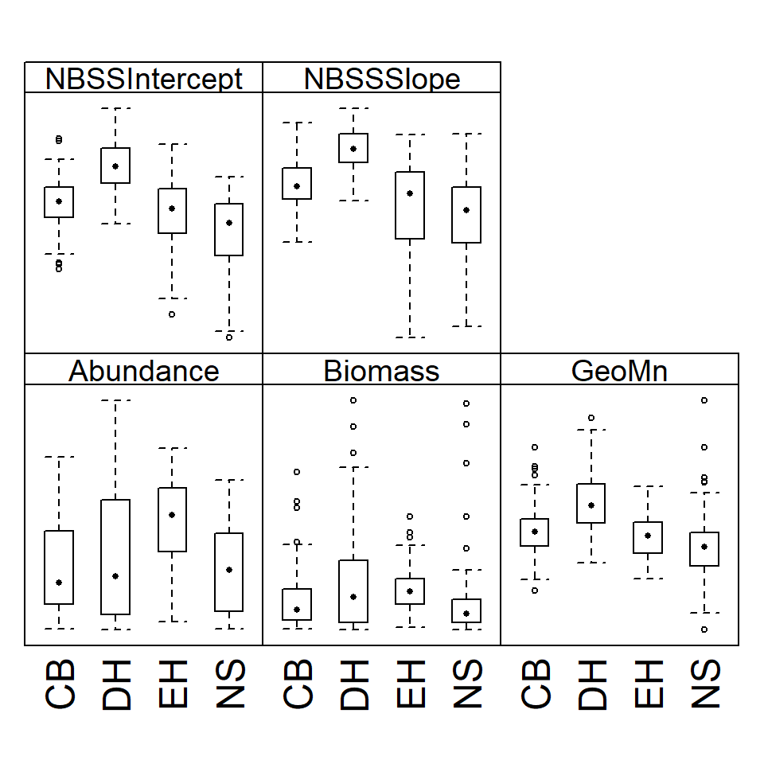

### Outliers

#### Outliers in X variables (there are none)

NB: Order of the plots is from North - South (CB, EH, NS, DH), followed by all sites pooled.

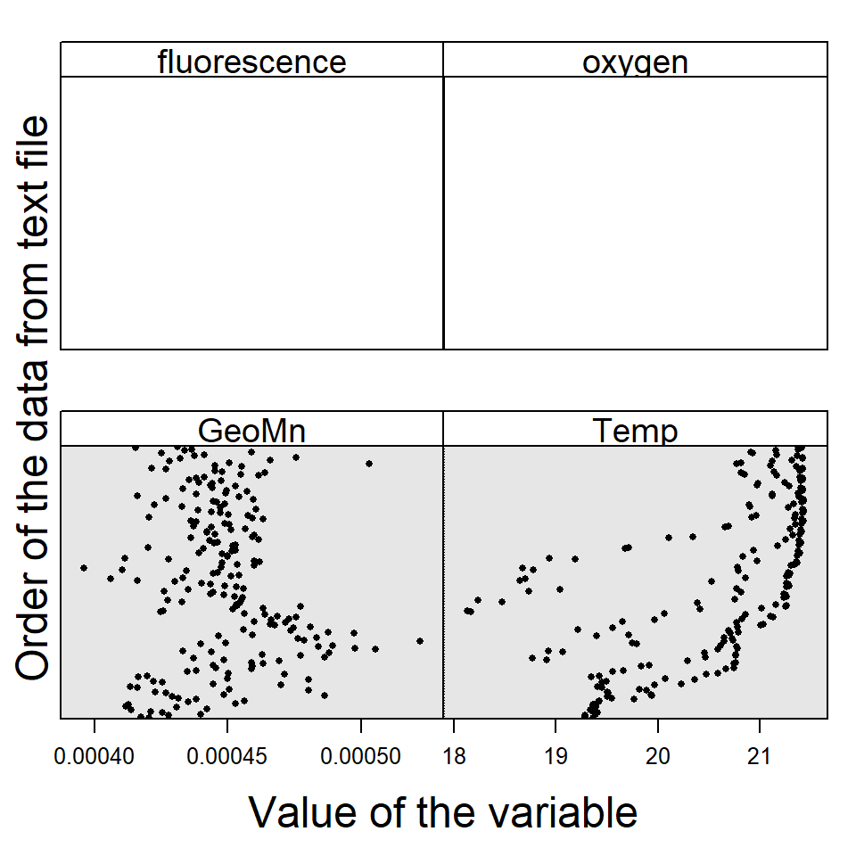

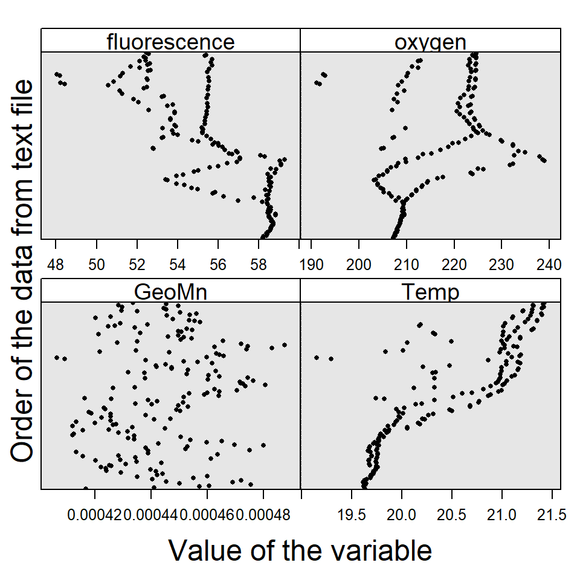

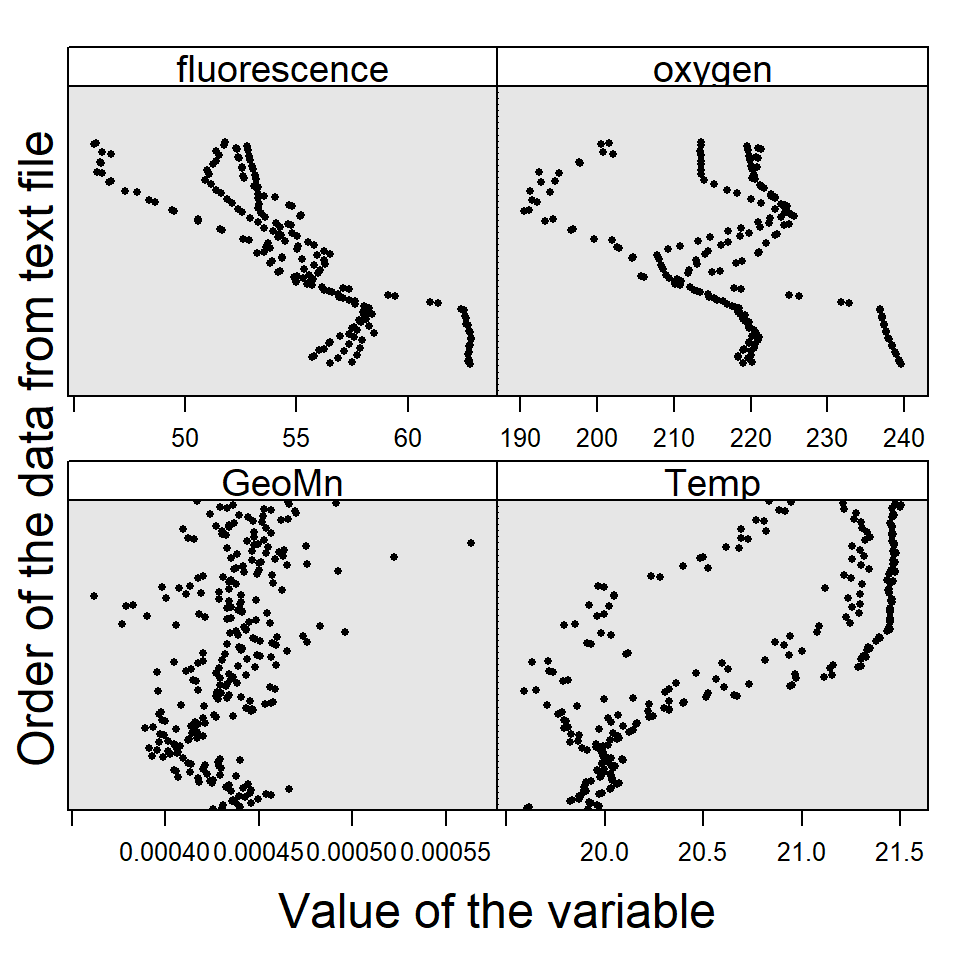

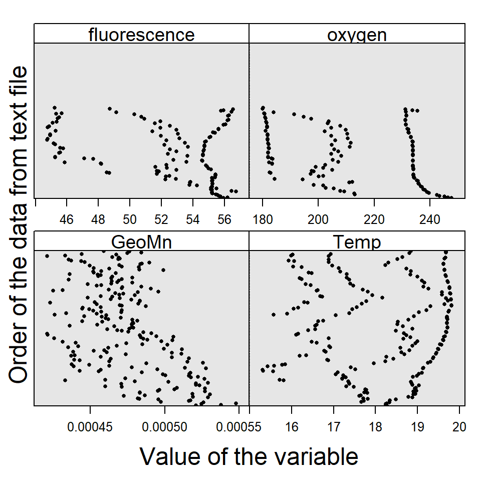

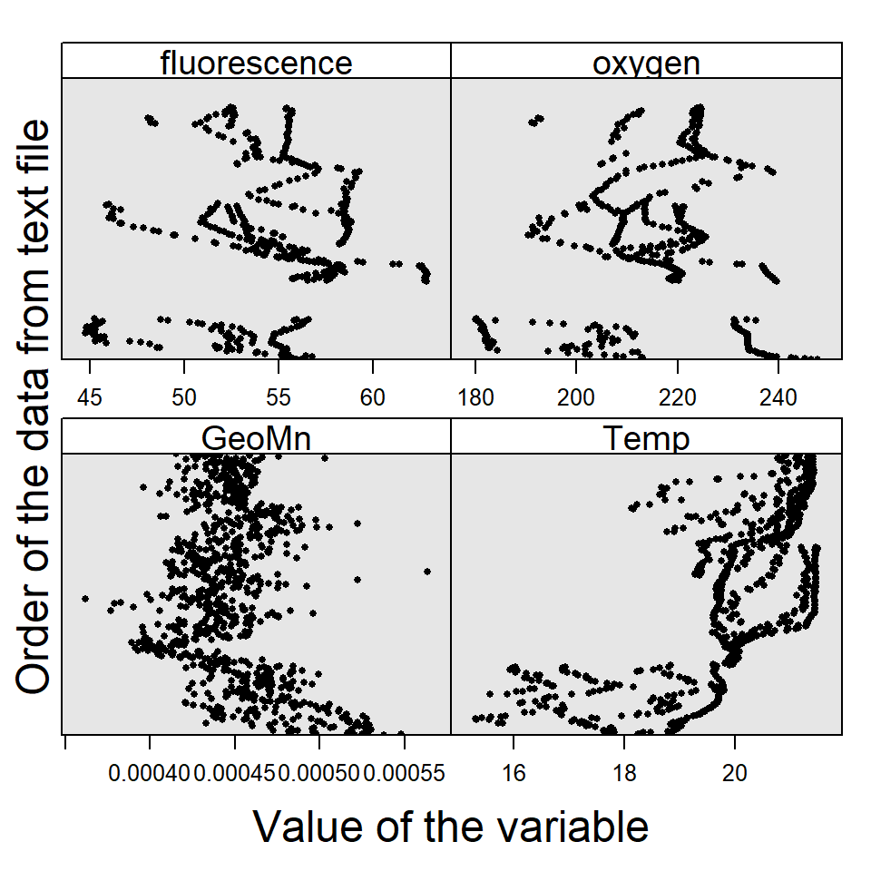

### Outliers in y

I decide to filter data to Biomass to < 2000. Everything else looks ok. NB: Order of the plots is from North - South (CB, EH, NS, DH), followed by all sites pooled.

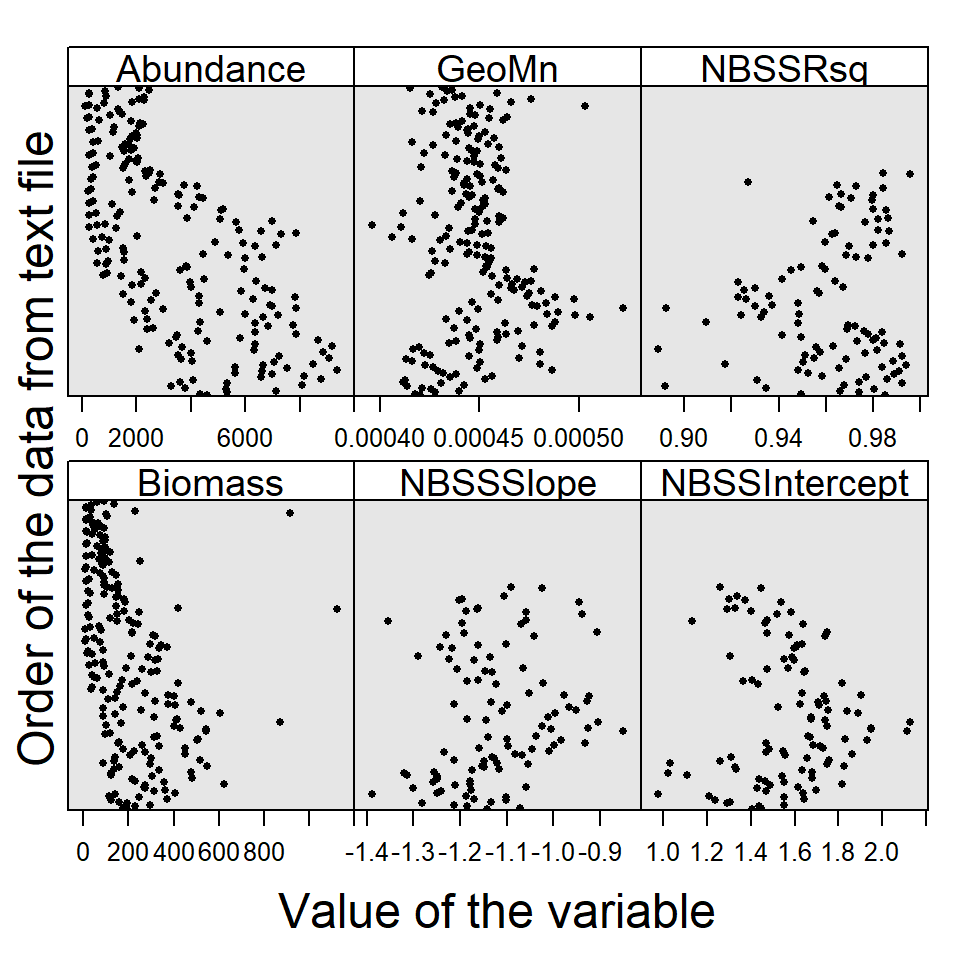

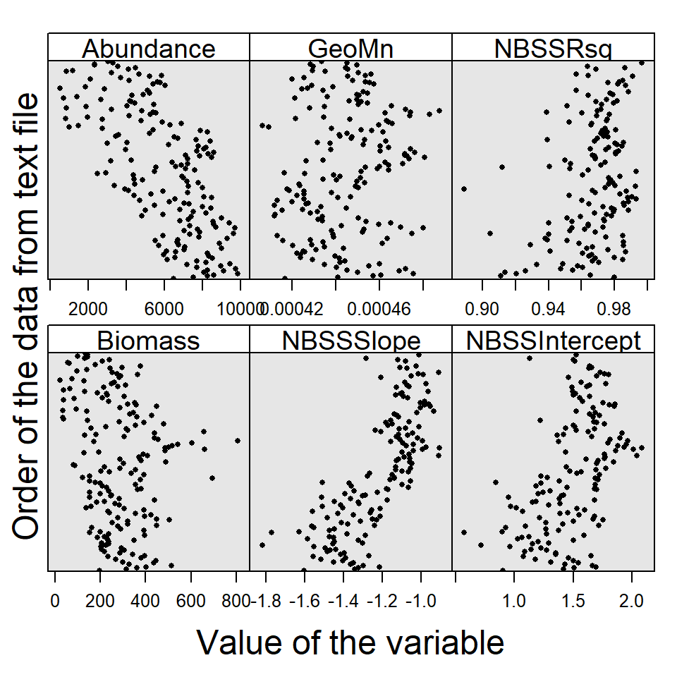

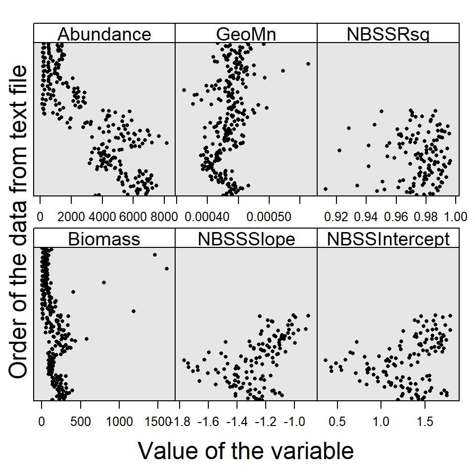

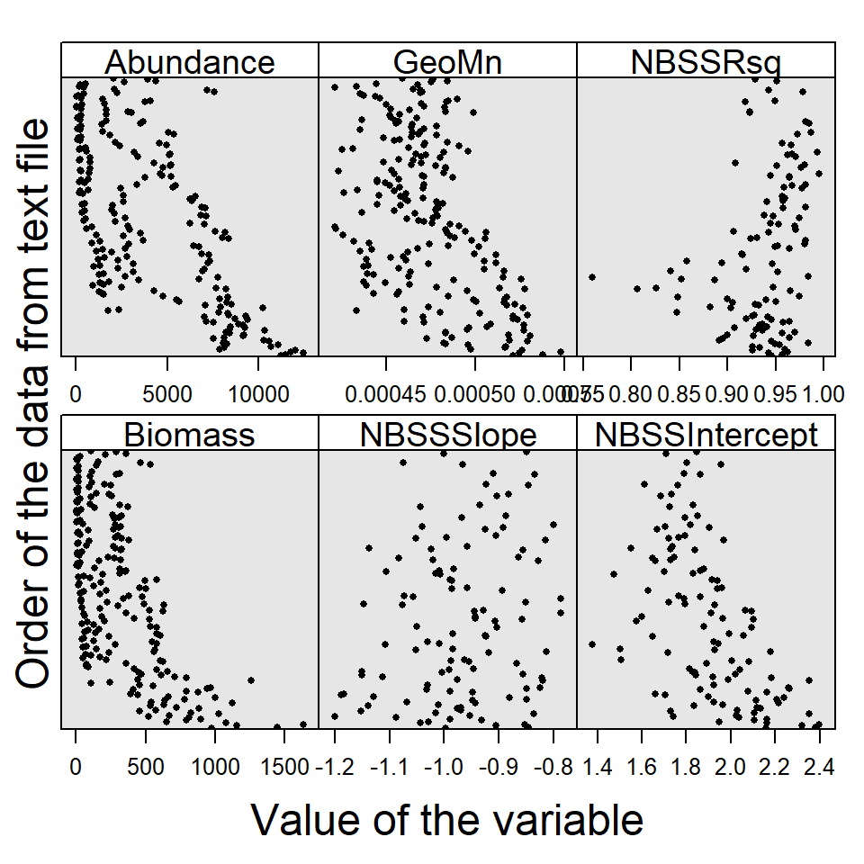

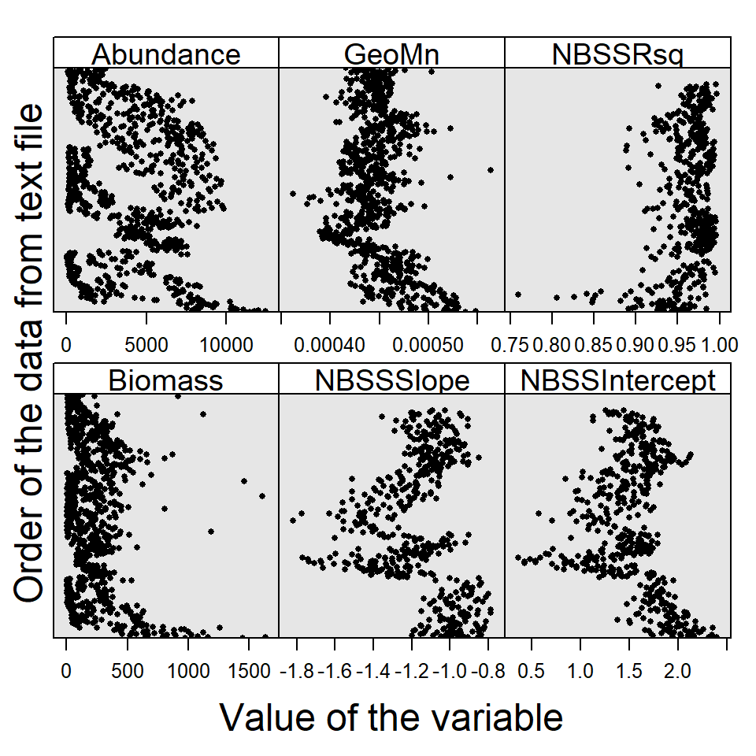